# Retail Sales Analysis: Superstore Dataset

## Sales Trends Over Time Visualization

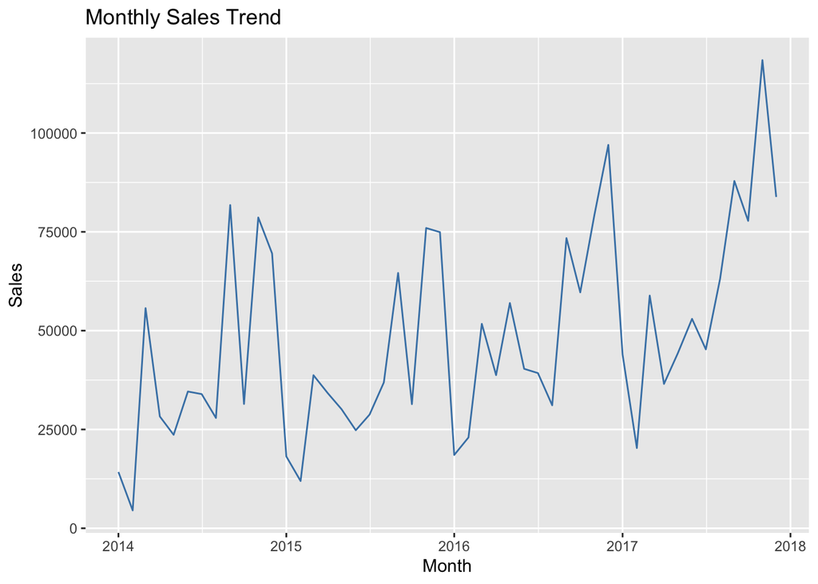

```r
superstore_df %>%
  mutate(month = floor_date(order_date, "month")) %>%
  group_by(month) %>%
  summarize(monthly_sales = sum(sales, na.rm = TRUE)) %>%
  ggplot(aes(x = month, y = monthly_sales)) +
  geom_line(color = "steelblue") +
  labs(title = "Monthly Sales Trend", x = "Month", y = "Sales")
```

## Regional Performance Visualization

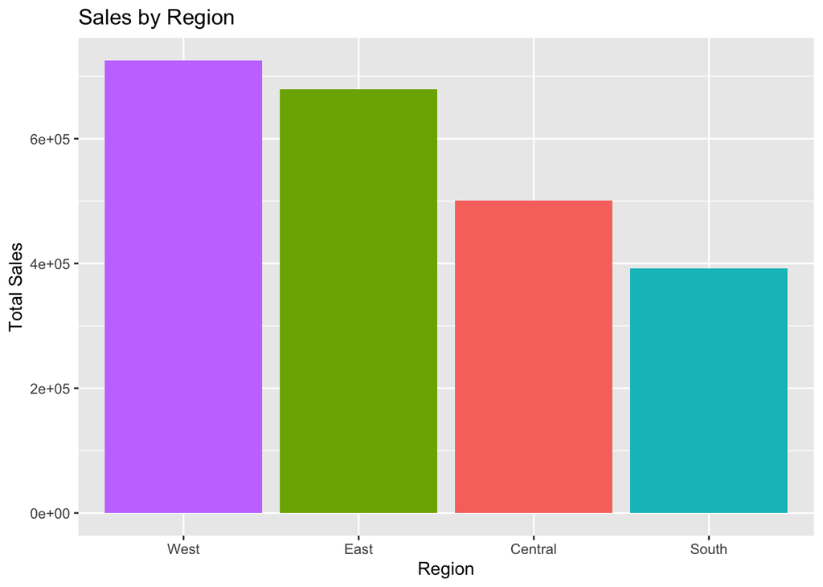

```r
superstore_df %>%
  group_by(region) %>%
  summarize(total_sales = sum(sales, na.rm = TRUE)) %>%
  ggplot(aes(x = reorder(region, -total_sales), y = total_sales, fill = region)) +
  geom_col() +
  labs(title = "Sales by Region", x = "Region", y = "Total Sales") +
  theme(legend.position = "none")
```

## Customer Segment Analysis

**Sales and Profit by Customer Segment:**

```r
superstore_df %>%
  group_by(segment) %>%
  summarize(
    total_sales = sum(sales, na.rm = TRUE),
    total_profit = sum(profit, na.rm = TRUE),
    avg_profit_margin = mean(profit / sales, na.rm = TRUE),
    order_count = n()
  ) %>%
  arrange(desc(total_sales))
```

```
## # A tibble: 3 × 5
##   segment     total_sales total_profit avg_profit_margin order_count
##   <chr>             <dbl>        <dbl>             <dbl>       <int>
## 1 Consumer       1161401.      134119.             0.112        5191
## 2 Corporate       706146.       91979.             0.121        3020
## 3 Home Office     429653.       60299.             0.143        1783
```

While Consumers generate the most revenue, Home Office customers appear to be more profitable on average. This indicates that different customer types bring different types of value—volume vs. profitability—and may warrant distinct engagement strategies.

**Visualize Sales and Profit:**

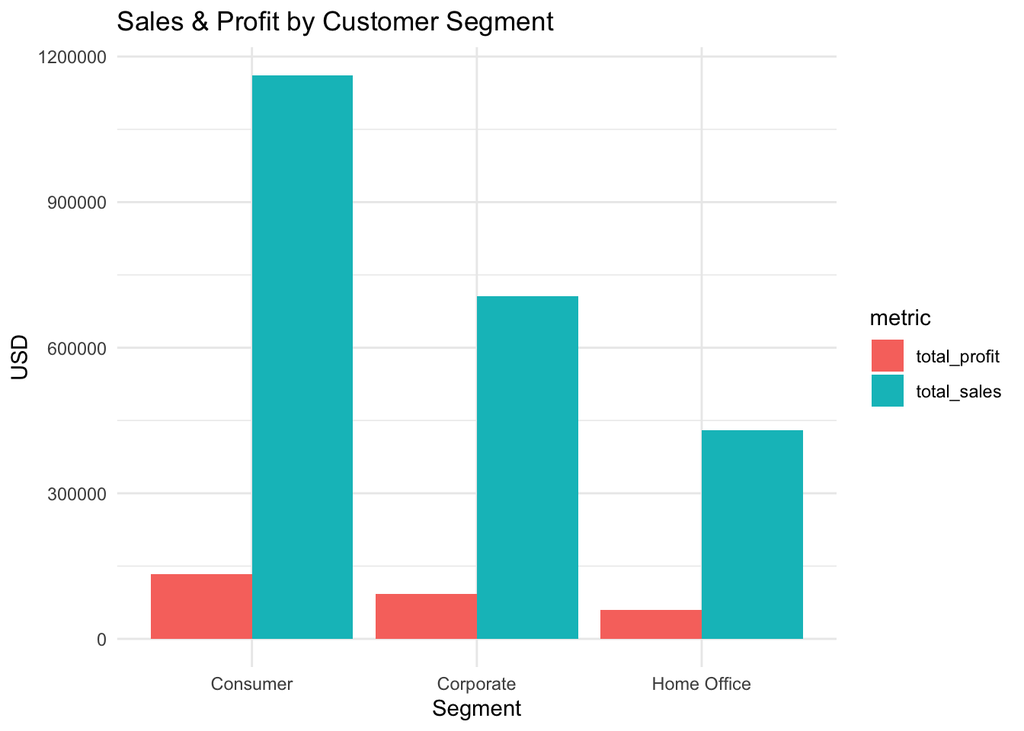

```r
superstore_df %>%
  group_by(segment) %>%
  summarize(
    total_sales = sum(sales, na.rm = TRUE),
    total_profit = sum(profit, na.rm = TRUE)
  ) %>%
  pivot_longer(cols = c(total_sales, total_profit), names_to = "metric", values_to = "value") %>%
  ggplot(aes(x = segment, y = value, fill = metric)) +
  geom_bar(stat = "identity", position = "dodge") +
  labs(title = "Sales & Profit by Customer Segment", x = "Segment", y = "USD") +
  theme_minimal()
```

**Visualize Sales by Segment + Region:**

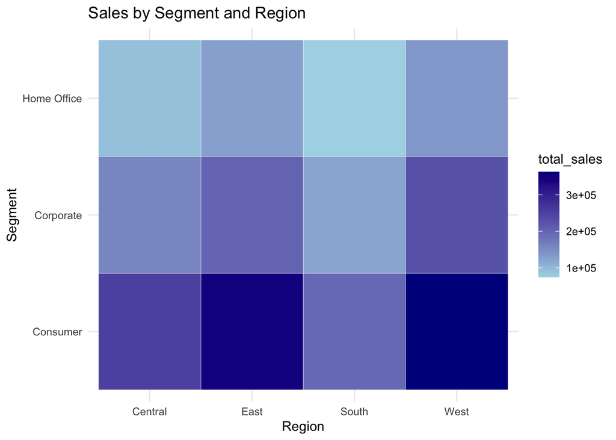

```r
superstore_df %>%
  group_by(segment, region) %>%
  summarize(total_sales = sum(sales, na.rm = TRUE)) %>%
  ggplot(aes(x = region, y = segment, fill = total_sales)) +
  geom_tile(color = "white") +
  scale_fill_gradient(low = "lightblue", high = "darkblue") +
  labs(title = "Sales by Segment and Region", x = "Region", y = "Segment") +
  theme_minimal()
```

## Profitability Breakdown

This analysis will help you understand where profit is actually coming from, regardless of sales volume. My goal is to identify which categories, sub-categories, or regions are driving or hurting profitability — even if their sales look good.

**Profitability by Category and Sub-Category:**

```r
superstore_df %>%
  group_by(category, sub_category) %>%
  summarize(
    total_sales = sum(sales, na.rm = TRUE),
    total_profit = sum(profit, na.rm = TRUE),
    profit_margin = total_profit / total_sales
  ) %>%
  arrange(desc(profit_margin))
```

```
## # A tibble: 17 × 5
## # Groups:   category [3]
##    category        sub_category total_sales total_profit profit_margin
##    <chr>           <chr>              <dbl>        <dbl>         <dbl>
##  1 Office Supplies Labels            12486.        5546.        0.444
##  2 Office Supplies Paper             78479.       34054.        0.434
##  3 Office Supplies Envelopes         16476.        6964.        0.423
##  4 Technology      Copiers          149528.       55618.        0.372
##  5 Office Supplies Fasteners          3024.         950.        0.314
##  6 Technology      Accessories      167380.       41937.        0.251
##  7 Office Supplies Art               27119.        6528.        0.241
##  8 Office Supplies Appliances       107532.       18138.        0.169
##  9 Office Supplies Binders          203413.       30222.        0.149
## 10 Furniture       Furnishings       91705.       13059.        0.142
## 11 Technology      Phones           330007.       44516.        0.135
## 12 Office Supplies Storage          223844.       21279.        0.0951
## 13 Furniture       Chairs           328449.       26590.        0.0810
## 14 Technology      Machines         189239.        3385.        0.0179
## 15 Office Supplies Supplies          46674.       -1189.       -0.0255
## 16 Furniture       Bookcases        114880.       -3473.       -0.0302
## 17 Furniture       Tables           206966.      -17725.       -0.0856
```

- Office Supplies like Labels, Paper, and Envelopes have the highest profit margins (> 40%).
- Some categories, such as Tables and Bookcases, show negative profitability.
- Profitability varies widely across sub-categories. Low-cost office supplies deliver strong margins, while some furniture items operate at a loss. This could be due to pricing issues, high return rates, or shipping costs. Product-level strategy adjustments may be needed.

**Visualize Profit Margin by Sub-Category:**

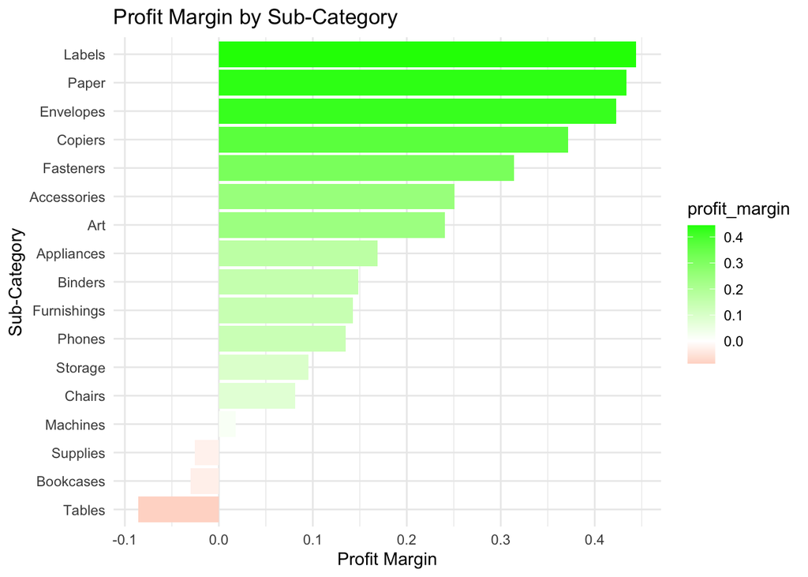

```r
superstore_df %>%
  group_by(sub_category) %>%
  summarize(
    total_sales = sum(sales, na.rm = TRUE),
    total_profit = sum(profit, na.rm = TRUE),
    profit_margin = total_profit / total_sales
  ) %>%
  ggplot(aes(x = reorder(sub_category, profit_margin), y = profit_margin, fill = profit_margin)) +
  geom_bar(stat = "identity") +
  coord_flip() +
  labs(title = "Profit Margin by Sub-Category", x = "Sub-Category", y = "Profit Margin") +
  scale_fill_gradient2(low = "red", high = "green", midpoint = 0) +
  theme_minimal()
```

**Identify Loss-Making Categories:**

```r
superstore_df %>%
  group_by(sub_category) %>%
  summarize(total_profit = sum(profit, na.rm = TRUE)) %>%
  filter(total_profit < 0) %>%
  arrange(total_profit)
```

```
## # A tibble: 3 × 2
##   sub_category total_profit
##   <chr>               <dbl>
## 1 Tables            -17725.
## 2 Bookcases          -3473.
## 3 Supplies           -1189.
```

- Tables, Bookcases, and Supplies sub-categories have negative overall profit.
- These are clear loss-makers. Their continued inclusion in the catalog may require strategic review, particularly regarding pricing, supplier costs, or delivery/logistics challenges.

**Profitability by Region:**

```r
superstore_df %>%
  group_by(region) %>%
  summarize(
    total_sales = sum(sales, na.rm = TRUE),
    total_profit = sum(profit, na.rm = TRUE),
    profit_margin = total_profit / total_sales
  ) %>%
  arrange(desc(profit_margin))
```

```
## # A tibble: 4 × 4
##   region  total_sales total_profit profit_margin
##   <chr>         <dbl>        <dbl>         <dbl>
## 1 West        725458.      108418.        0.149
## 2 East        678781.       91523.        0.135
## 3 South       391722.       46749.        0.119
## 4 Central     501240.       39706.        0.0792
```

- The West region shows the highest profit margin (14.9%), while Central has the lowest (7.9%).
- Regional differences are significant. The West outperforms in both sales and margin, indicating stronger market dynamics or customer base. Central’s lower margin may reflect operational inefficiencies or competitive pricing pressures.

# Key Business Insights

**1- Sales Are Concentrated in High-Value Items** A small number of expensive products (e.g., Canon Copiers, Cisco Systems) generate a disproportionately high share of revenue. This highlights the importance of prioritizing inventory management, pricing strategies, and targeted marketing efforts around these “high-ticket” items.

**2- Customer Segments Differ by Value Type** While the Consumer segment brings the highest total sales, the Home Office segment has the highest average profit margin. This suggests segmentation-based strategies: scale-focused for consumers, margin-focused for home office users.

**3- Sub-Category Profitability Is Highly Uneven** Office Supplies like Labels and Paper offer exceptional margins (above 40%), while Furniture items like Tables and Bookcases result in financial losses. These insights point to opportunities for product rationalization and profit optimization.

**4- Negative-Profit Sub-Categories Need Attention** Tables and Bookcases consistently generate losses. Root causes (e.g., high shipping cost, overstock, discounting) should be investigated, and pricing or portfolio strategies revised.

**5- West Region Leads in Profitability** The West region achieves both high sales and the highest profit margin (14.9%), suggesting a robust customer base or effective operations. Conversely, the Central region shows underperformance and requires further analysis.

# Conclusion

This analysis uncovered key areas of opportunity for the business to optimize profitability and streamline its product portfolio. High-value technology items and office supplies drive revenue and margins, whereas select furniture categories require attention. Regional and segment-level patterns suggest targeted strategies to unlock further value. With improved data granularity and longitudinal tracking, future analysis can better inform pricing, marketing, and inventory decisions.

# Future Work

Future analyses could:

- analyze loss-making products by customer segment, region, and season to understand drivers,
- incorporate customer-level purchase patterns over time to assess CLV by segment,
- use time-series models to forecast demand and identify trends in top-performing categories,
- explore how discounts or promotions affect profit margins in different categories.